# Topic 4-02: Single sample GSEA

Zuguang Gu z.gu@dkfz.de

2025-05-23

We need an expression matrix as well as a collection of gene sets.

```r
lt = readRDS(system.file("extdata", "p53_expr.rds", package = "GSEAtraining"))
expr = lt$expr
condition = lt$condition

ln = strsplit(readLines(system.file("extdata", "c2.symbols.gmt", package = "GSEAtraining")), "\t")
gs = lapply(ln, function(x) x[-(1:2)])
names(gs) = sapply(ln, function(x) x[1])
```

## GSEA per sample

The implementation is quite straightforward. As GSEA expects a vector of gene scores, expression of all genes in a single sample can also be thought of as a type of gene scores. What we do is only to make sure such expression is relative and corresponds to “differential expression” of genes in that single sample. This means we need to do a proper normalization or scaling across samples.

We use the simplest normalization method: z-score normalization:

```r
expr_scaled = t(scale(t(expr)))
```

The gene set level score in a sample should capture both up- and down-regulation. The default method in GSEA already can capture it by taking the maximal deviation of two CDFs for genes in and not in the gene set, and keeping the sign. GSVA also uses another metric, which is the difference between the maximal positive deviation and the maximal negative deviation. We implement both:

```r
es_score = function(s, gene_sets, power = 1, method = c("std", "diff")) {
    n = length(s)
    ngs = length(gene_sets)
    es = numeric(ngs)

    method = match.arg(method)[1]

    for(i in seq_len(ngs)) {
        l_set = names(s) %in% gene_sets[[i]]

        s_set = numeric(n)
        s_set[l_set] = abs(s[l_set])^power

        l_other = !l_set

        f1 = cumsum(s_set)/sum(s_set)
        f2 = cumsum(l_other)/sum(l_other)
        m1 = max(f1 - f2)
        m2 = min(f1 - f2)

        if(method == "std") {
            es[i] = max(abs(m1), abs(m2)) * ifelse(abs(m1) > abs(m2), sign(m1), sign(m2))
        } else {
            if(m1 >= 0 && m2 >= 0) {
                es[i] = max(m1, m2)
            } else if(m1 <= 0 && m2 <= 0) {
                es[i] = min(m1, m2)
            } else {
                es[i] = m1 + m2
            }
        }
    }

    es
}
```

Now we can go over each sample and calculate a geneset-sample matrix. Let’s do it for both “std” and “diff” methods

```r
mat_gs1_std = matrix(nrow = length(gs), ncol = ncol(expr))
rownames(mat_gs1_std) = names(gs)
for(i in 1:ncol(expr)) {
    mat_gs1_std[, i] = es_score(sort(expr_scaled[, i], decreasing = TRUE), gs, method = "std")
}

mat_gs1_diff = matrix(nrow = length(gs), ncol = ncol(expr))
rownames(mat_gs1_diff) = names(gs)
for(i in 1:ncol(expr)) {
    mat_gs1_diff[, i] = es_score(sort(expr_scaled[, i], decreasing = TRUE), gs, method = "diff")
}
```

In GSVA, instead of using the normalized expression values, it uses the ranked values as weights. We also calculate it by two ES methods:

```r
mat_gs2_std = matrix(nrow = length(gs), ncol = ncol(expr))
rownames(mat_gs2_std) = names(gs)
for(i in 1:ncol(expr)) {
    v = rank(expr_scaled[, i]) - nrow(expr_scaled)/2
    mat_gs2_std[, i] = es_score(sort(v, decreasing = TRUE), gs, method = "std")
}

mat_gs2_diff = matrix(nrow = length(gs), ncol = ncol(expr))
rownames(mat_gs2_diff) = names(gs)
for(i in 1:ncol(expr)) {
    v = rank(expr_scaled[, i]) - nrow(expr_scaled)/2
    mat_gs2_diff[, i] = es_score(sort(v, decreasing = TRUE), gs, method = "diff")
}
```

Let’s compare the four matrices:

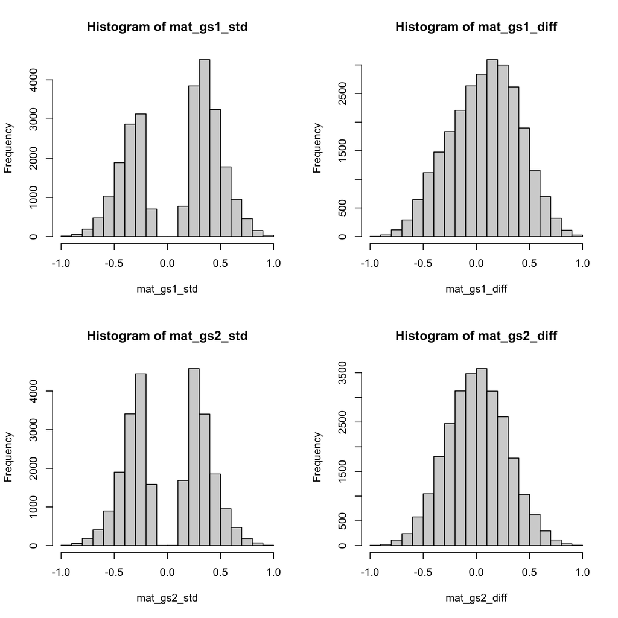

```r
par(mfrow = c(2, 2))
hist(mat_gs1_std)
hist(mat_gs1_diff)
hist(mat_gs2_std)
hist(mat_gs2_diff)
```

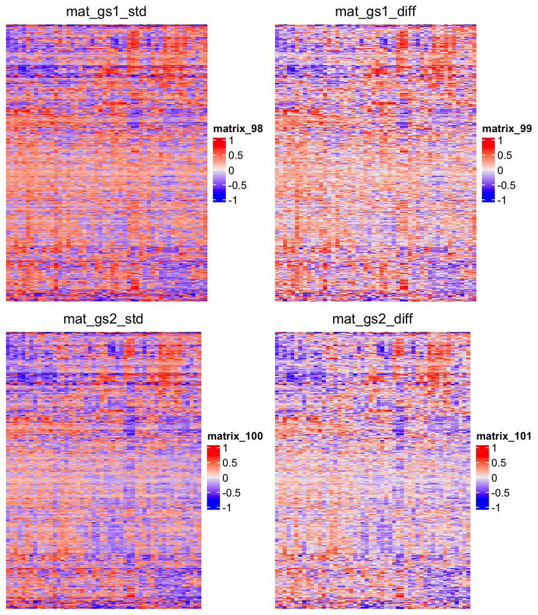

```r
library(ComplexHeatmap)
rod = hclust(dist(mat_gs1_std))$order
cod = hclust(dist(t(mat_gs1_std)))$order

p1 = grid.grabExpr(draw(Heatmap(mat_gs1_std, row_order = rod, column_order = cod, show_row_names = FALSE, column_title = "mat_gs1_std")))
p2 = grid.grabExpr(draw(Heatmap(mat_gs1_diff, row_order = rod, column_order = cod, show_row_names = FALSE, column_title = "mat_gs1_diff")))
p3 = grid.grabExpr(draw(Heatmap(mat_gs2_std, row_order = rod, column_order = cod, show_row_names = FALSE, column_title = "mat_gs2_std")))
p4 = grid.grabExpr(draw(Heatmap(mat_gs2_diff, row_order = rod, column_order = cod, show_row_names = FALSE, column_title = "mat_gs2_diff")))

library(cowplot)
plot_grid(p1, p2, p3, p4, nrow = 2)
```

## GSVA

Next we run the **GSVA** package.

```r
library(GSVA)
mat_gs_gsva = gsva(gsvaParam(log(expr), gs), verbose = FALSE)
```

You can do a log-transformation, this is optional. **GSVA** uses CDF to normalize expression values.

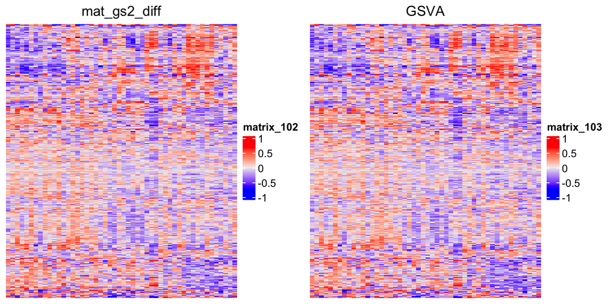

```r
p4 = grid.grabExpr(draw(Heatmap(mat_gs2_diff, row_order = rod, column_order = cod, show_row_names = FALSE, column_title = "mat_gs2_diff")))
p5 = grid.grabExpr(draw(Heatmap(mat_gs_gsva, row_order = rod, column_order = cod, show_row_names = FALSE, show_column_names = FALSE, column_title = "GSVA")))
plot_grid(p4, p5, nrow = 1)
```

## What to do with the geneset-sample matrix

```r
library(genefilter)
# high stat means high in MUT
tdf = rowttests(mat_gs2_std, factor(condition, levels = c("MUT", "WT")))
tdf$fdr = p.adjust(tdf$p.value, "BH")
tdf = tdf[order(tdf$p.value), ]
```

How many gene sets are significant?

```r
tdf[tdf$fdr < 0.05, ]
```

```
##            statistic        dm      p.value        fdr
## ngfPathway  4.511968 0.3582107 4.153293e-05 0.02168019
```

## Compare to normal GSEA

The next natural question is, compared to normal GSEA analysis, does GSVA improves the analysis? or how consistent is between the two types of analysis?

The `tdf` object already contains differential analysis on the geneset-sample matrix and it gives significant gene sets. For the normal GSEA analysis, we use the same setting as before.

```r
library(matrixStats)
m1 = expr[, condition == "WT"]  # only samples in group 1
m2 = expr[, condition == "MUT"]  # only samples in group 2
s = (rowMeans(m2) - rowMeans(m1))/(rowSds(m1) + rowSds(m2)) # gene-level difference scores
s = sort(s, decreasing = TRUE)

tb_gsea = fgsea_wrapper(s, gs)
```

Most significant gene sets from the two methods:

```r
head(tdf)
```

```
##                statistic         dm      p.value        fdr
## ngfPathway      4.511968  0.3582107 4.153293e-05 0.02168019
## igf1Pathway     3.809559  0.3281558 3.958583e-04 0.05168996
## erkPathway      3.768718  0.2901213 4.491493e-04 0.05168996
## rasPathway      3.762046  0.3225174 4.584864e-04 0.05168996
## insulinPathway  3.737078  0.3097062 4.951146e-04 0.05168996
## hsp27Pathway   -3.652174 -0.3226910 6.418985e-04 0.05584517
```

```r
head(tb_gsea)
```

```
##                       gene_set      p_value    p_adjust log2_p_err         es
## 1                       P53_UP 3.789642e-06 0.001366504  0.6272567 -0.5986774
## 2                 hsp27Pathway 5.554895e-06 0.001366504  0.6105269 -0.7758925
## 3                     HTERT_UP 1.592124e-05 0.002611084  0.5756103  0.3709129
## 4                   p53Pathway 3.094204e-05 0.003805871  0.5573322 -0.7438596
## 5 GPCRs_Class_A_Rhodopsin-like 6.309031e-05 0.006208087  0.5384341 -0.4299558
## 6            p53hypoxiaPathway 1.059682e-04 0.007570592  0.5384341 -0.6816006
##         nes n_gs leading_edge
## 1 -2.108583   40 CDKN1A, ....
## 2 -2.166991   15 TNFRSF6,....
## 3  1.886180  109 AHR, DR1....
## 4 -2.131422   16 CDKN1A, ....
## 5 -1.842049  111 NTSR2, A....
## 6 -2.074471   20 CDKN1A, ....
```

And top 50 gene sets from the two methods:

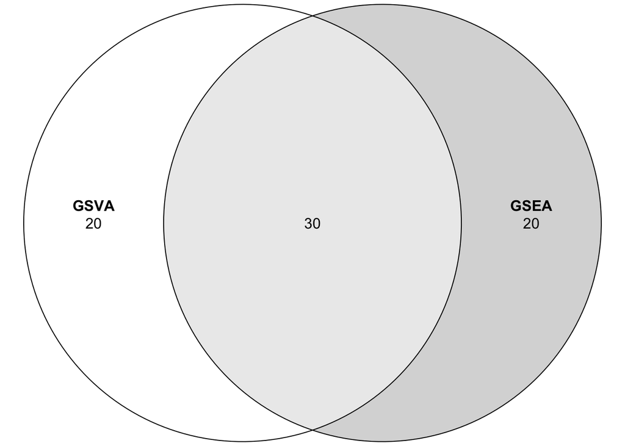

```r
library(eulerr)
plot(euler(list(GSVA = rownames(tdf)[order(tdf$p.value)[1:50]],
                GSEA = tb_gsea$gene_set[order(tb_gsea$p_value)[1:50]])
          ), quantities = TRUE)
```

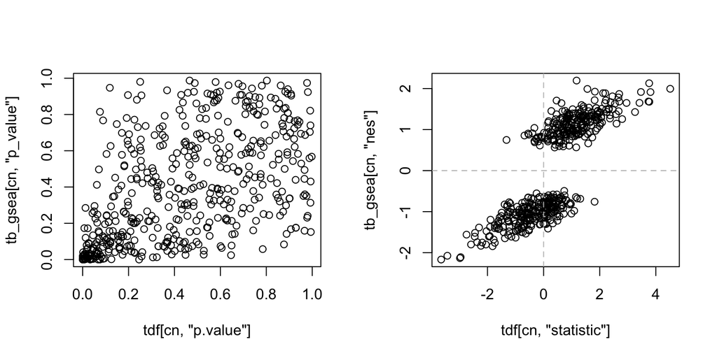

```r
rownames(tb_gsea) = tb_gsea$gene_set
cn = intersect(rownames(tdf), rownames(tb_gsea))
par(mfrow = c(1, 2))
plot(tdf[cn, "p.value"], tb_gsea[cn, "p_value"])
plot(tdf[cn, "statistic"], tb_gsea[cn, "nes"])
abline(h = 0, lty = 2, col = "grey")
abline(v = 0, lty = 2, col = "grey")
```

This makes a problem here that one method generates a significant gene set which can be completely insignificant under another method (left plot). The direction of the general differentiation of a gene set can be reversed in different methods.

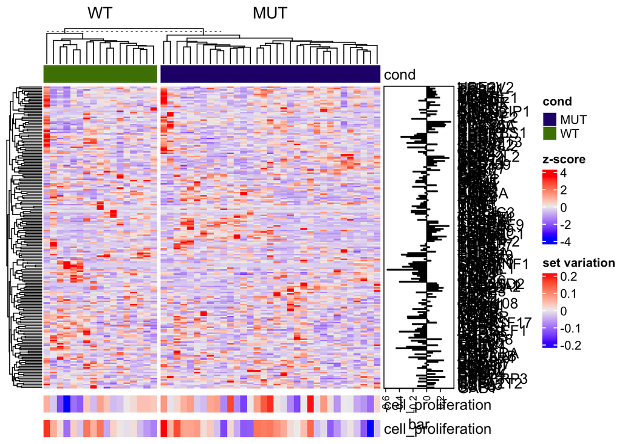

```r
g = intersect(gs[["cell_proliferation"]], rownames(expr))
mm = expr_scaled[g, ]

Heatmap(mm, name = "z-score", top_annotation = HeatmapAnnotation(cond = condition),
    right_annotation = rowAnnotation(bar = anno_barplot(s[g], width = unit(2, "cm"))),
    column_split = condition) %v%
Heatmap(mat_gs_gsva["cell_proliferation", , drop = FALSE], name = "set variation", height = unit(5, "mm")) %v%
Heatmap(mat_gs1_diff["cell_proliferation", , drop = FALSE], name = "set variation", height = unit(5, "mm"))
```

## Compare to gene-based analysis

Can geneset-sample matrix reduce the noise from the original gene-sample matrix?

```r
library(cola)
res1 = consensus_partition(mat_gs_gsva, top_value_method = "ATC", partition_method = "skmeans", verbose = FALSE)
get_signatures(res1, k = suggest_best_k(res1))
```

```
## The best k suggested by this function might not reflect the real
## subgroups in the data (especially when you expect a large best k). It
## is recommended to directly look at the plots from
## select_partition_number() or other related plotting functions.
```

```
## * 48/50 samples (in 2 classes) remain after filtering by silhouette (>= 0.5).
## * cache hash: 39e1da0fdcfd7600c28b151bae8b311a (seed 888).
## * calculating row difference between subgroups by Ftest.
## * split rows into 2 groups by k-means clustering.
## * 202 signatures (38.7%) under fdr < 0.05, group_diff > 0.
## * making heatmaps for signatures.
```

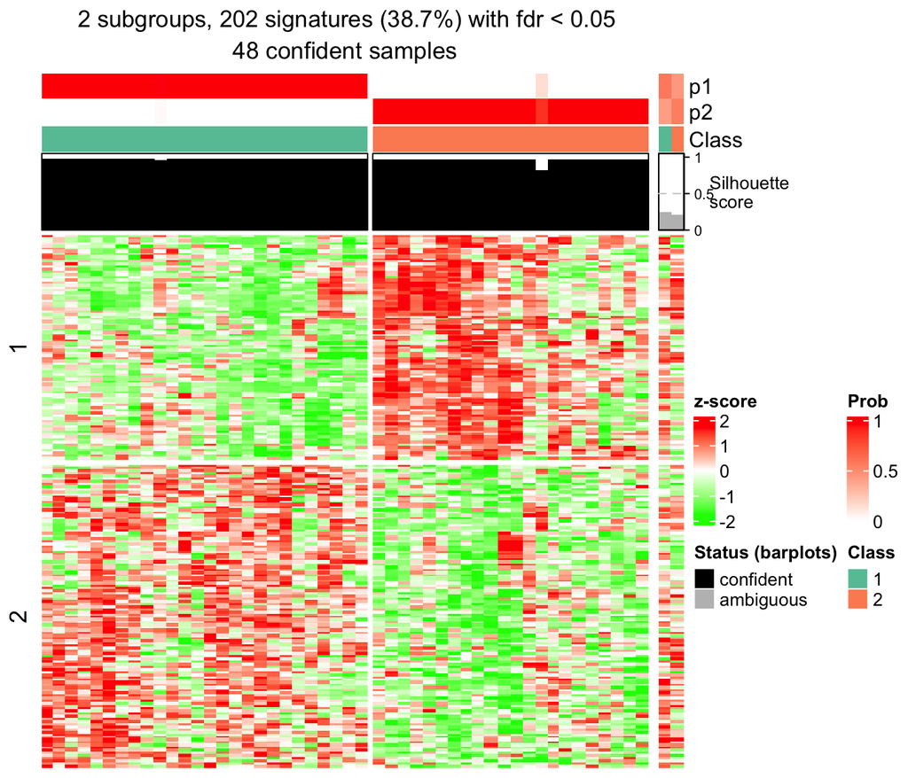

```r
res2 = consensus_partition(expr, top_value_method = "ATC", partition_method = "skmeans", verbose = FALSE)
get_signatures(res2, k = suggest_best_k(res2))
```

```
## The best k suggested by this function might not reflect the real
## subgroups in the data (especially when you expect a large best k). It
## is recommended to directly look at the plots from
## select_partition_number() or other related plotting functions.
```

```
## * 47/50 samples (in 3 classes) remain after filtering by silhouette (>= 0.5).
## * cache hash: bc04608b057107f6119adf50c97e81b1 (seed 888).
## * calculating row difference between subgroups by Ftest.
## * split rows into 3 groups by k-means clustering.
## * 2148 signatures (21.3%) under fdr < 0.05, group_diff > 0.
##   - randomly sample 2000 signatures.
## * making heatmaps for signatures.
```

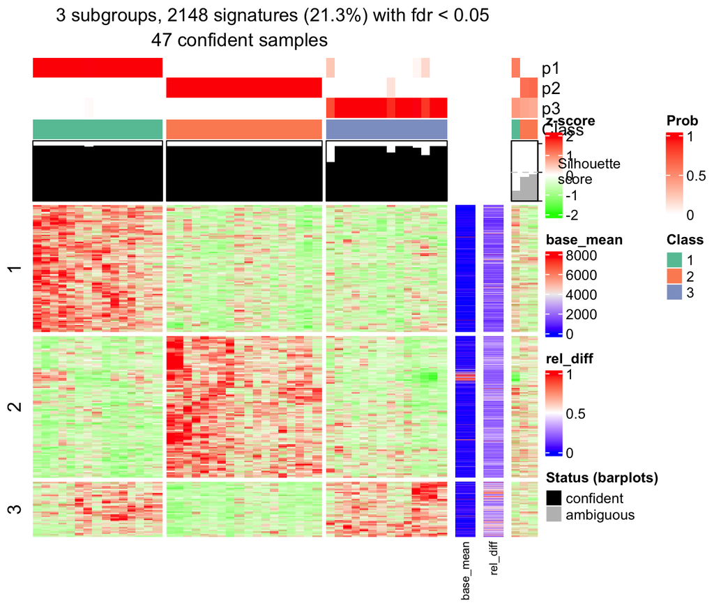